# Module 57

#### Contrast SVE:

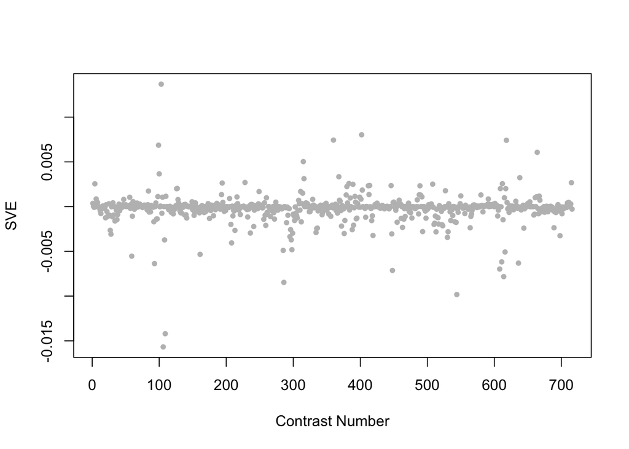

Positive SVE Contrasts:

|  | Contrast.Num | SVE | GEO.GSE | Cond.1 | Cond.2 | Mutation |
| --- | --- | --- | --- | --- | --- | --- |
| GSE5793.s3t2.vs.s3t1 | 103 | 0.01 | GSE5793 | Celegans_PA14_8hours_RepA | Celegans_PA14_4hours_RepA |  |
| GSE30505.s1t2.vs.s2t2 | 402 | 0.01 | GSE30505 | Day 8 N2 (WT) E.V. #1 | Day 8 N2 (WT) ash-2 #1 | ash-2 |
| GSE37432.s1t1.vs.s0t1 | 360 | 0.01 | GSE37432 | piwi n4357 n4358 rep1 | N2 rep1 | prg-1;prg-2 |
| GSE21591.s1t1.vs.s2t1 | 618 | 0.01 | GSE21591 | N2_aFLAG_1 | Input_1 |  |
| GSE5793.s3t2.vs.s1t2 | 99 | 0.01 | GSE5793 | Celegans_PA14_8hours_RepA | Celegans_gacA_8hours_RepA |  |

Negative SVE Contrasts:

|  | Contrast.Num | SVE | GEO.GSE | Cond.1 | Cond.2 | Mutation |
| --- | --- | --- | --- | --- | --- | --- |
| GSE54513.s3t1.vs.s1t1 | 106 | -0.02 | GSE54513 | spe-9 input rep1 | fog-1 input rep1 |  |
| GSE54513.s4t1.vs.s2t1 | 109 | -0.01 | GSE54513 | spe-9 OMA-1 IP rep1 | fog-1 OMA-1 IP rep1 |  |
| GSE2180.s4t2.vs.s3t2 | 544 | -0.01 | GSE2180 | pp23-1 | p23-2 | pal-1(RNAi) |
| GSE41366C.s1t1.vs.s0t1 | 286 | -0.01 | GSE41366 | low_DDVP-continuous_expose-2h_harvest-rep1 | control-continuous_expose-0h_harvest-rep2 |  |
| GSE21591.s2t1.vs.s4t1 | 614 | -0.01 | GSE21591 | Input_1 | aMYC_1 |  |

$~$

#### Contrast SVE, Up-Regulated Genes Only:

Calculating SVE for up-regulated and down-regulated genes separately may be more informative in many cases than projecting the up- and down- gene sets together. This is due to the fact that the weight distribution of many modules is highly skewed, indicating that only one of the hemi-modules may be biologically meaningful (i.e., a set of genes are strongly correlated by only a few genes (or none) are strongly anti-correlated to that set.)

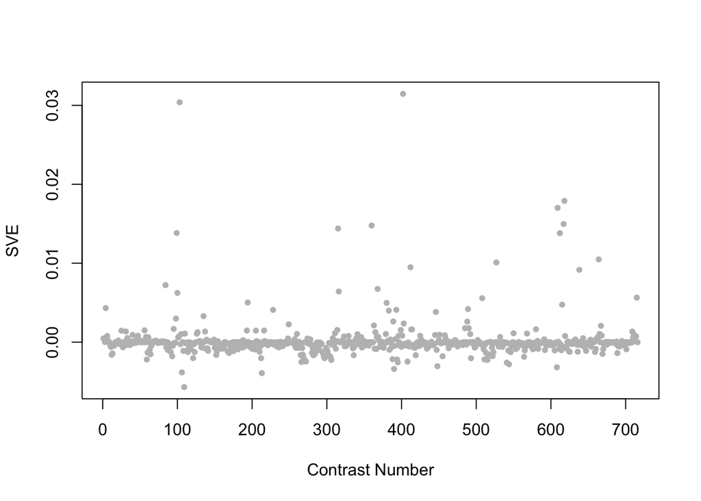

Positive SVE Contrasts:

|  | Contrast.Num | SVE | GEO.GSE | Cond.1 | Cond.2 | Mutation |
| --- | --- | --- | --- | --- | --- | --- |
| GSE30505.s1t2.vs.s2t2 | 402 | 0.03 | GSE30505 | Day 8 N2 (WT) E.V. #1 | Day 8 N2 (WT) ash-2 #1 | ash-2 |
| GSE5793.s3t2.vs.s3t1 | 103 | 0.03 | GSE5793 | Celegans_PA14_8hours_RepA | Celegans_PA14_4hours_RepA |  |
| GSE21591.s1t1.vs.s2t1 | 618 | 0.02 | GSE21591 | N2_aFLAG_1 | Input_1 |  |
| GSE21591.s4t1.vs.s5t1 | 609 | 0.02 | GSE21591 | aMYC_1 | aFLAG_1 |  |
| GSE21591.s1t1.vs.s3t1 | 617 | 0.01 | GSE21591 | N2_aFLAG_1 | GGF_aFLAG_1 |  |

Negative SVE Contrasts:

|  | Contrast.Num | SVE | GEO.GSE | Cond.1 | Cond.2 | Mutation |
| --- | --- | --- | --- | --- | --- | --- |
| GSE54513.s4t1.vs.s2t1 | 109 | -0.01 | GSE54513 | spe-9 OMA-1 IP rep1 | fog-1 OMA-1 IP rep1 |  |
| GSE42689.s4t1.vs.s2t1 | 213 | -0.00 | GSE42689 | mlk-1 fed 1 | mek-1 fed 1 |  |
| GSE54513.s3t1.vs.s1t1 | 106 | -0.00 | GSE54513 | spe-9 input rep1 | fog-1 input rep1 |  |
| GSE32521.s1t1.vs.s0t1 | 390 | -0.00 | GSE32521 | Au-NP Replicate1 | Control Replicate1 |  |
| GSE21747.s1t1.vs.s0t1 | 608 | -0.00 | GSE21747 | albendazole exposure, biological rep 1 | no albendazole exposure, biological rep 1 |  |

$~$

#### Contrast SVE, Down-Regulated Genes Only:

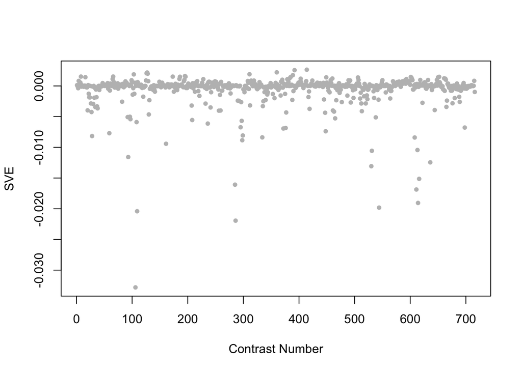

Positive SVE Contrasts:

|  | Contrast.Num | SVE | GEO.GSE | Cond.1 | Cond.2 | Mutation |
| --- | --- | --- | --- | --- | --- | --- |
| GSE29951.s1t1.vs.s0t1 | 414 | 0.00 | GSE29951 | C.elegans MT KO mtl-1,mtl-2(zs1), raised in the absence of Cd, rep1 | C.elegans wild type raised in the absence of Cd, rep1 | mtl-1;mtl-2 |
| GSE32339.s1t2.vs.s0t2 | 392 | 0.00 | GSE32339 | Adult Mutant, biological rep1 | Adult Wild-type, biological rep1 | nep-1 |
| GSE37432.s1t1.vs.s0t1 | 360 | 0.00 | GSE37432 | piwi n4357 n4358 rep1 | N2 rep1 | prg-1;prg-2 |
| GSE54011.s2t1.vs.s0t1 | 127 | 0.00 | GSE54011 | Ce 0.1 mM Se | Ce 0 mM Se |  |
| GSE54011.s1t1.vs.s0t1 | 126 | 0.00 | GSE54011 | Ce 0.05 mM Se | Ce 0 mM Se |  |

Negative SVE Contrasts:

|  | Contrast.Num | SVE | GEO.GSE | Cond.1 | Cond.2 | Mutation |
| --- | --- | --- | --- | --- | --- | --- |
| GSE54513.s3t1.vs.s1t1 | 106 | -0.03 | GSE54513 | spe-9 input rep1 | fog-1 input rep1 |  |
| GSE41366C.s1t1.vs.s0t1 | 286 | -0.02 | GSE41366 | low_DDVP-continuous_expose-2h_harvest-rep1 | control-continuous_expose-0h_harvest-rep2 |  |
| GSE54513.s4t1.vs.s2t1 | 109 | -0.02 | GSE54513 | spe-9 OMA-1 IP rep1 | fog-1 OMA-1 IP rep1 |  |
| GSE2180.s4t2.vs.s3t2 | 544 | -0.02 | GSE2180 | pp23-1 | p23-2 | pal-1(RNAi) |
| GSE21591.s2t1.vs.s4t1 | 614 | -0.02 | GSE21591 | Input_1 | aMYC_1 |  |

$~$

$~$

#### GO Term Enrichment:

This analysis tests each hemi-module for enrichment of specific GO terms. Only gene-level annotations (e.g., as would be found on the gene’s page in Wormbase) are tested - the hierarchical structure of the GO ontology is not taken into account.

*Note: At least the top two most enriched terms from each GO domain (BP/MF/CC) are shown, even when not statistically significant.*

##### Enriched GO terms: Hemi-module A

| ID | GO.Term | GO Domain | Raw p-value | Adj p-value |
| --- | --- | --- | --- | --- |
| [GO_0007016](http://amigo.geneontology.org/amigo/term/GO:0007016) | cytoskeletal anchoring at plasma membrane | BP | 1.75e-03 | 9.94e-01 |
| [GO_0051209](http://amigo.geneontology.org/amigo/term/GO:0051209) | release of sequestered calcium ion into cytosol | BP | 3.68e-03 | 9.94e-01 |
| [GO_0008410](http://amigo.geneontology.org/amigo/term/GO:0008410) | CoA-transferase activity | MF | 2.56e-04 | 5.23e-01 |
| [GO_0005515](http://amigo.geneontology.org/amigo/term/GO:0005515) | protein binding | MF | 9.12e-03 | 9.97e-01 |
| [GO_1904115](http://amigo.geneontology.org/amigo/term/GO:1904115) | axon cytoplasm | CC | 3.68e-03 | 9.95e-01 |
| [GO_0005925](http://amigo.geneontology.org/amigo/term/GO:0005925) | focal adhesion | CC | 8.33e-03 | 9.95e-01 |

##### Enriched GO terms: Hemi-module B

| ID | GO.Term | GO Domain | Raw p-value | Adj p-value |
| --- | --- | --- | --- | --- |
| [GO_0006418](http://amigo.geneontology.org/amigo/term/GO:0006418) | tRNA aminoacylation for protein translation | BP | 8.33e-04 | 1.00e+00 |
| [GO_0042660](http://amigo.geneontology.org/amigo/term/GO:0042660) | positive regulation of cell fate specification | BP | 1.66e-03 | 1.00e+00 |
| [GO_0004812](http://amigo.geneontology.org/amigo/term/GO:0004812) | aminoacyl-tRNA ligase activity | MF | 1.34e-03 | 1.00e+00 |
| [GO_0050480](http://amigo.geneontology.org/amigo/term/GO:0050480) | imidazolonepropionase activity | MF | 1.66e-03 | 1.00e+00 |
| [GO_0005751](http://amigo.geneontology.org/amigo/term/GO:0005751) | mitochondrial respiratory chain complex IV | CC | 8.28e-03 | 1.00e+00 |
| [GO_0030014](http://amigo.geneontology.org/amigo/term/GO:0030014) | CCR4-NOT complex | CC | 9.93e-03 | 1.00e+00 |

$~$

$~$

#### Tissue Enrichment:

This analysis tests each hemi-module for enrichment of genes associated with anatomy terms. Negative enrichment scores indicate fewer hemi-module genes than expected by random chance were associated with the anatomy term in question.

##### Enriched tissues: Hemi-module A

No significant annotations.

##### Enriched tissues: Hemi-module B

No significant annotations.

$~$

$~$

#### HOMER promoter motif enrichment:

This analysis tests each hemi-module for enrichment of 108 known *C. elegans* transcription factor binding site motifs (see [108 CE motifs](https://katiepod.github.io//all.worm.motifs.html)) using the HOMER (Hypergeometric Optimization of Motif EnRichment) software (see [PMID:20513432](https://pubmed.ncbi.nlm.nih.gov/20513432)). HOMER was run using default parameters on sequences 1 kb upstream of the transcription start site.

##### Motif enrichment: Hemi-module A

Total target sequences = 180  
Total background sequences = 39583  
* - possible false positive

Rank

Motif

P-value

log P-pvalue

% of Targets

% of Background

STD(Bg STD)

Best Match/Details

Motif File

1 *

[figure not shown]

1e-10

-2.487e+01

3.89%

0.05%

248.6bp (270.0bp)

MF0001.1_ETS_class/Jaspar(0.555)  
[More Information](https://katiepod.github.io/HomerResults/m57_a_hemi_genes.txt.out.1kb/homerResults/motif1.info.html) | [Similar Motifs Found](https://katiepod.github.io/HomerResults/m57_a_hemi_genes.txt.out.1kb/homerResults/motif1.similar.html)

[motif file (matrix)](https://katiepod.github.io/HomerResults/m57_a_hemi_genes.txt.out.1kb/homerResults/motif1.motif)

2 *

[figure not shown]

1e-10

-2.487e+01

3.89%

0.05%

193.1bp (202.3bp)

MF0011.1_HMG_class/Jaspar(0.658)  
[More Information](https://katiepod.github.io/HomerResults/m57_a_hemi_genes.txt.out.1kb/homerResults/motif2.info.html) | [Similar Motifs Found](https://katiepod.github.io/HomerResults/m57_a_hemi_genes.txt.out.1kb/homerResults/motif2.similar.html)

[motif file (matrix)](https://katiepod.github.io/HomerResults/m57_a_hemi_genes.txt.out.1kb/homerResults/motif2.motif)

3 *

[figure not shown]

1e-10

-2.487e+01

12.78%

2.16%

287.9bp (293.4bp)

PL0015.1_hlh-2::hlh-14/Jaspar(0.644)  
[More Information](https://katiepod.github.io/HomerResults/m57_a_hemi_genes.txt.out.1kb/homerResults/motif3.info.html) | [Similar Motifs Found](https://katiepod.github.io/HomerResults/m57_a_hemi_genes.txt.out.1kb/homerResults/motif3.similar.html)

[motif file (matrix)](https://katiepod.github.io/HomerResults/m57_a_hemi_genes.txt.out.1kb/homerResults/motif3.motif)

4 *

[figure not shown]

1e-9

-2.204e+01

21.11%

6.69%

263.1bp (304.9bp)

MF0002.1_bZIP_CREB/G-box-like_subclass/Jaspar(0.589)  
[More Information](https://katiepod.github.io/HomerResults/m57_a_hemi_genes.txt.out.1kb/homerResults/motif4.info.html) | [Similar Motifs Found](https://katiepod.github.io/HomerResults/m57_a_hemi_genes.txt.out.1kb/homerResults/motif4.similar.html)

[motif file (matrix)](https://katiepod.github.io/HomerResults/m57_a_hemi_genes.txt.out.1kb/homerResults/motif4.motif)

5 *

[figure not shown]

1e-8

-2.017e+01

10.00%

1.64%

358.3bp (290.0bp)

POL012.1_TATA-Box/Jaspar(0.577)  
[More Information](https://katiepod.github.io/HomerResults/m57_a_hemi_genes.txt.out.1kb/homerResults/motif5.info.html) | [Similar Motifs Found](https://katiepod.github.io/HomerResults/m57_a_hemi_genes.txt.out.1kb/homerResults/motif5.similar.html)

[motif file (matrix)](https://katiepod.github.io/HomerResults/m57_a_hemi_genes.txt.out.1kb/homerResults/motif5.motif)

6 *

[figure not shown]

1e-8

-2.014e+01

7.22%

0.74%

241.1bp (291.5bp)

cebp-1/MA1444.1/Jaspar(0.467)  
[More Information](https://katiepod.github.io/HomerResults/m57_a_hemi_genes.txt.out.1kb/homerResults/motif6.info.html) | [Similar Motifs Found](https://katiepod.github.io/HomerResults/m57_a_hemi_genes.txt.out.1kb/homerResults/motif6.similar.html)

[motif file (matrix)](https://katiepod.github.io/HomerResults/m57_a_hemi_genes.txt.out.1kb/homerResults/motif6.motif)

7 *

[figure not shown]

1e-8

-2.010e+01

11.11%

2.08%

288.5bp (312.8bp)

MF0003.1_REL_class/Jaspar(0.745)  
[More Information](https://katiepod.github.io/HomerResults/m57_a_hemi_genes.txt.out.1kb/homerResults/motif7.info.html) | [Similar Motifs Found](https://katiepod.github.io/HomerResults/m57_a_hemi_genes.txt.out.1kb/homerResults/motif7.similar.html)

[motif file (matrix)](https://katiepod.github.io/HomerResults/m57_a_hemi_genes.txt.out.1kb/homerResults/motif7.motif)

8 *

[figure not shown]

1e-8

-1.982e+01

23.33%

8.61%

297.4bp (315.8bp)

POL010.1_DCE_S_III/Jaspar(0.570)  
[More Information](https://katiepod.github.io/HomerResults/m57_a_hemi_genes.txt.out.1kb/homerResults/motif8.info.html) | [Similar Motifs Found](https://katiepod.github.io/HomerResults/m57_a_hemi_genes.txt.out.1kb/homerResults/motif8.similar.html)

[motif file (matrix)](https://katiepod.github.io/HomerResults/m57_a_hemi_genes.txt.out.1kb/homerResults/motif8.motif)

9 *

[figure not shown]

1e-8

-1.982e+01

8.33%

1.09%

258.6bp (284.7bp)

lin-14/MA0261.1/Jaspar(0.591)  
[More Information](https://katiepod.github.io/HomerResults/m57_a_hemi_genes.txt.out.1kb/homerResults/motif9.info.html) | [Similar Motifs Found](https://katiepod.github.io/HomerResults/m57_a_hemi_genes.txt.out.1kb/homerResults/motif9.similar.html)

[motif file (matrix)](https://katiepod.github.io/HomerResults/m57_a_hemi_genes.txt.out.1kb/homerResults/motif9.motif)

10 *

[figure not shown]

1e-8

-1.937e+01

12.22%

2.64%

320.9bp (319.1bp)

SD0002.1_at_AC_acceptor/Jaspar(0.640)  
[More Information](https://katiepod.github.io/HomerResults/m57_a_hemi_genes.txt.out.1kb/homerResults/motif10.info.html) | [Similar Motifs Found](https://katiepod.github.io/HomerResults/m57_a_hemi_genes.txt.out.1kb/homerResults/motif10.similar.html)

[motif file (matrix)](https://katiepod.github.io/HomerResults/m57_a_hemi_genes.txt.out.1kb/homerResults/motif10.motif)

11 *

[figure not shown]

1e-8

-1.920e+01

5.56%

0.39%

249.3bp (290.4bp)

che-1/MA0260.1/Jaspar(0.533)  
[More Information](https://katiepod.github.io/HomerResults/m57_a_hemi_genes.txt.out.1kb/homerResults/motif11.info.html) | [Similar Motifs Found](https://katiepod.github.io/HomerResults/m57_a_hemi_genes.txt.out.1kb/homerResults/motif11.similar.html)

[motif file (matrix)](https://katiepod.github.io/HomerResults/m57_a_hemi_genes.txt.out.1kb/homerResults/motif11.motif)

12 *

[figure not shown]

1e-8

-1.919e+01

6.11%

0.51%

240.8bp (260.6bp)

sma-4/MA0925.1/Jaspar(0.738)  
[More Information](https://katiepod.github.io/HomerResults/m57_a_hemi_genes.txt.out.1kb/homerResults/motif12.info.html) | [Similar Motifs Found](https://katiepod.github.io/HomerResults/m57_a_hemi_genes.txt.out.1kb/homerResults/motif12.similar.html)

[motif file (matrix)](https://katiepod.github.io/HomerResults/m57_a_hemi_genes.txt.out.1kb/homerResults/motif12.motif)

13 *

[figure not shown]

1e-8

-1.906e+01

2.78%

0.03%

315.9bp (335.9bp)

ceh-22/MA0264.1/Jaspar(0.562)  
[More Information](https://katiepod.github.io/HomerResults/m57_a_hemi_genes.txt.out.1kb/homerResults/motif13.info.html) | [Similar Motifs Found](https://katiepod.github.io/HomerResults/m57_a_hemi_genes.txt.out.1kb/homerResults/motif13.similar.html)

[motif file (matrix)](https://katiepod.github.io/HomerResults/m57_a_hemi_genes.txt.out.1kb/homerResults/motif13.motif)

14 *

[figure not shown]

1e-8

-1.893e+01

4.44%

0.20%

244.6bp (289.0bp)

fkh-2/MA0920.1/Jaspar(0.544)  
[More Information](https://katiepod.github.io/HomerResults/m57_a_hemi_genes.txt.out.1kb/homerResults/motif14.info.html) | [Similar Motifs Found](https://katiepod.github.io/HomerResults/m57_a_hemi_genes.txt.out.1kb/homerResults/motif14.similar.html)

[motif file (matrix)](https://katiepod.github.io/HomerResults/m57_a_hemi_genes.txt.out.1kb/homerResults/motif14.motif)

15 *

[figure not shown]

1e-8

-1.871e+01

8.89%

1.39%

273.7bp (296.5bp)

elt-2/MA1701.1/Jaspar(0.523)  
[More Information](https://katiepod.github.io/HomerResults/m57_a_hemi_genes.txt.out.1kb/homerResults/motif15.info.html) | [Similar Motifs Found](https://katiepod.github.io/HomerResults/m57_a_hemi_genes.txt.out.1kb/homerResults/motif15.similar.html)

[motif file (matrix)](https://katiepod.github.io/HomerResults/m57_a_hemi_genes.txt.out.1kb/homerResults/motif15.motif)

16 *

[figure not shown]

1e-8

-1.865e+01

16.67%

4.98%

294.1bp (298.6bp)

lin-54/MA1450.1/Jaspar(0.574)  
[More Information](https://katiepod.github.io/HomerResults/m57_a_hemi_genes.txt.out.1kb/homerResults/motif16.info.html) | [Similar Motifs Found](https://katiepod.github.io/HomerResults/m57_a_hemi_genes.txt.out.1kb/homerResults/motif16.similar.html)

[motif file (matrix)](https://katiepod.github.io/HomerResults/m57_a_hemi_genes.txt.out.1kb/homerResults/motif16.motif)

17 *

[figure not shown]

1e-8

-1.864e+01

3.33%

0.07%

275.5bp (267.0bp)

POL013.1_MED-1/Jaspar(0.628)  
[More Information](https://katiepod.github.io/HomerResults/m57_a_hemi_genes.txt.out.1kb/homerResults/motif17.info.html) | [Similar Motifs Found](https://katiepod.github.io/HomerResults/m57_a_hemi_genes.txt.out.1kb/homerResults/motif17.similar.html)

[motif file (matrix)](https://katiepod.github.io/HomerResults/m57_a_hemi_genes.txt.out.1kb/homerResults/motif17.motif)

18 *

[figure not shown]

1e-7

-1.809e+01

3.33%

0.08%

346.7bp (332.7bp)

efl-1/MA0541.1/Jaspar(0.512)  
[More Information](https://katiepod.github.io/HomerResults/m57_a_hemi_genes.txt.out.1kb/homerResults/motif18.info.html) | [Similar Motifs Found](https://katiepod.github.io/HomerResults/m57_a_hemi_genes.txt.out.1kb/homerResults/motif18.similar.html)

[motif file (matrix)](https://katiepod.github.io/HomerResults/m57_a_hemi_genes.txt.out.1kb/homerResults/motif18.motif)

19 *

[figure not shown]

1e-7

-1.769e+01

10.56%

2.16%

331.2bp (293.7bp)

MF0009.1_TRP(MYB)_class/Jaspar(0.637)  
[More Information](https://katiepod.github.io/HomerResults/m57_a_hemi_genes.txt.out.1kb/homerResults/motif19.info.html) | [Similar Motifs Found](https://katiepod.github.io/HomerResults/m57_a_hemi_genes.txt.out.1kb/homerResults/motif19.similar.html)

[motif file (matrix)](https://katiepod.github.io/HomerResults/m57_a_hemi_genes.txt.out.1kb/homerResults/motif19.motif)

20 *

[figure not shown]

1e-7

-1.670e+01

7.22%

1.00%

261.2bp (327.7bp)

unc-86/MA0926.1/Jaspar(0.525)  
[More Information](https://katiepod.github.io/HomerResults/m57_a_hemi_genes.txt.out.1kb/homerResults/motif20.info.html) | [Similar Motifs Found](https://katiepod.github.io/HomerResults/m57_a_hemi_genes.txt.out.1kb/homerResults/motif20.similar.html)

[motif file (matrix)](https://katiepod.github.io/HomerResults/m57_a_hemi_genes.txt.out.1kb/homerResults/motif20.motif)

21 *

[figure not shown]

1e-7

-1.660e+01

17.78%

6.12%

303.0bp (308.9bp)

POL006.1_BREu/Jaspar(0.558)  
[More Information](https://katiepod.github.io/HomerResults/m57_a_hemi_genes.txt.out.1kb/homerResults/motif21.info.html) | [Similar Motifs Found](https://katiepod.github.io/HomerResults/m57_a_hemi_genes.txt.out.1kb/homerResults/motif21.similar.html)

[motif file (matrix)](https://katiepod.github.io/HomerResults/m57_a_hemi_genes.txt.out.1kb/homerResults/motif21.motif)

22 *

[figure not shown]

1e-6

-1.608e+01

5.00%

0.41%

284.1bp (292.8bp)

PQM-1(?)/cElegans-L3-ChIP-Seq(modEncode)/Homer(0.757)  
[More Information](https://katiepod.github.io/HomerResults/m57_a_hemi_genes.txt.out.1kb/homerResults/motif22.info.html) | [Similar Motifs Found](https://katiepod.github.io/HomerResults/m57_a_hemi_genes.txt.out.1kb/homerResults/motif22.similar.html)

[motif file (matrix)](https://katiepod.github.io/HomerResults/m57_a_hemi_genes.txt.out.1kb/homerResults/motif22.motif)

23 *

[figure not shown]

1e-6

-1.508e+01

19.44%

7.61%

274.8bp (337.3bp)

DPL-1(E2F)/cElegans-Adult-ChIP-Seq(modEncode)/Homer(0.653)  
[More Information](https://katiepod.github.io/HomerResults/m57_a_hemi_genes.txt.out.1kb/homerResults/motif23.info.html) | [Similar Motifs Found](https://katiepod.github.io/HomerResults/m57_a_hemi_genes.txt.out.1kb/homerResults/motif23.similar.html)

[motif file (matrix)](https://katiepod.github.io/HomerResults/m57_a_hemi_genes.txt.out.1kb/homerResults/motif23.motif)

24 *

[figure not shown]

1e-6

-1.503e+01

3.33%

0.14%

258.2bp (293.0bp)

unc-62/MA0918.1/Jaspar(0.630)  
[More Information](https://katiepod.github.io/HomerResults/m57_a_hemi_genes.txt.out.1kb/homerResults/motif24.info.html) | [Similar Motifs Found](https://katiepod.github.io/HomerResults/m57_a_hemi_genes.txt.out.1kb/homerResults/motif24.similar.html)

[motif file (matrix)](https://katiepod.github.io/HomerResults/m57_a_hemi_genes.txt.out.1kb/homerResults/motif24.motif)

25 *

[figure not shown]

1e-6

-1.487e+01

12.22%

3.44%

226.2bp (292.7bp)

PL0008.1_hlh-29/Jaspar(0.629)  
[More Information](https://katiepod.github.io/HomerResults/m57_a_hemi_genes.txt.out.1kb/homerResults/motif25.info.html) | [Similar Motifs Found](https://katiepod.github.io/HomerResults/m57_a_hemi_genes.txt.out.1kb/homerResults/motif25.similar.html)

[motif file (matrix)](https://katiepod.github.io/HomerResults/m57_a_hemi_genes.txt.out.1kb/homerResults/motif25.motif)

26 *

[figure not shown]

1e-6

-1.485e+01

6.11%

0.80%

314.4bp (305.2bp)

dsc-1/MA0919.1/Jaspar(0.599)  
[More Information](https://katiepod.github.io/HomerResults/m57_a_hemi_genes.txt.out.1kb/homerResults/motif26.info.html) | [Similar Motifs Found](https://katiepod.github.io/HomerResults/m57_a_hemi_genes.txt.out.1kb/homerResults/motif26.similar.html)

[motif file (matrix)](https://katiepod.github.io/HomerResults/m57_a_hemi_genes.txt.out.1kb/homerResults/motif26.motif)

27 *

[figure not shown]

1e-6

-1.476e+01

39.44%

22.71%

282.4bp (302.1bp)

MF0011.1_HMG_class/Jaspar(0.581)  
[More Information](https://katiepod.github.io/HomerResults/m57_a_hemi_genes.txt.out.1kb/homerResults/motif27.info.html) | [Similar Motifs Found](https://katiepod.github.io/HomerResults/m57_a_hemi_genes.txt.out.1kb/homerResults/motif27.similar.html)

[motif file (matrix)](https://katiepod.github.io/HomerResults/m57_a_hemi_genes.txt.out.1kb/homerResults/motif27.motif)

28 *

[figure not shown]

1e-6

-1.422e+01

11.67%

3.28%

270.8bp (322.4bp)

POL010.1_DCE_S_III/Jaspar(0.622)  
[More Information](https://katiepod.github.io/HomerResults/m57_a_hemi_genes.txt.out.1kb/homerResults/motif28.info.html) | [Similar Motifs Found](https://katiepod.github.io/HomerResults/m57_a_hemi_genes.txt.out.1kb/homerResults/motif28.similar.html)

[motif file (matrix)](https://katiepod.github.io/HomerResults/m57_a_hemi_genes.txt.out.1kb/homerResults/motif28.motif)

29 *

[figure not shown]

1e-6

-1.386e+01

4.44%

0.40%

240.0bp (310.3bp)

POL007.1_BREd/Jaspar(0.505)  
[More Information](https://katiepod.github.io/HomerResults/m57_a_hemi_genes.txt.out.1kb/homerResults/motif29.info.html) | [Similar Motifs Found](https://katiepod.github.io/HomerResults/m57_a_hemi_genes.txt.out.1kb/homerResults/motif29.similar.html)

[motif file (matrix)](https://katiepod.github.io/HomerResults/m57_a_hemi_genes.txt.out.1kb/homerResults/motif29.motif)

30 *

[figure not shown]

1e-5

-1.207e+01

13.33%

4.74%

298.6bp (298.2bp)

ceh-48/MA0921.1/Jaspar(0.516)  
[More Information](https://katiepod.github.io/HomerResults/m57_a_hemi_genes.txt.out.1kb/homerResults/motif30.info.html) | [Similar Motifs Found](https://katiepod.github.io/HomerResults/m57_a_hemi_genes.txt.out.1kb/homerResults/motif30.similar.html)

[motif file (matrix)](https://katiepod.github.io/HomerResults/m57_a_hemi_genes.txt.out.1kb/homerResults/motif30.motif)

31 *

[figure not shown]

1e-5

-1.177e+01

2.22%

0.06%

286.4bp (333.6bp)

elt-3/MA0542.1/Jaspar(0.527)  
[More Information](https://katiepod.github.io/HomerResults/m57_a_hemi_genes.txt.out.1kb/homerResults/motif31.info.html) | [Similar Motifs Found](https://katiepod.github.io/HomerResults/m57_a_hemi_genes.txt.out.1kb/homerResults/motif31.similar.html)

[motif file (matrix)](https://katiepod.github.io/HomerResults/m57_a_hemi_genes.txt.out.1kb/homerResults/motif31.motif)

32 *

[figure not shown]

1e-4

-1.069e+01

7.22%

1.76%

295.3bp (303.3bp)

PL0008.1_hlh-29/Jaspar(0.676)  
[More Information](https://katiepod.github.io/HomerResults/m57_a_hemi_genes.txt.out.1kb/homerResults/motif32.info.html) | [Similar Motifs Found](https://katiepod.github.io/HomerResults/m57_a_hemi_genes.txt.out.1kb/homerResults/motif32.similar.html)

[motif file (matrix)](https://katiepod.github.io/HomerResults/m57_a_hemi_genes.txt.out.1kb/homerResults/motif32.motif)

33 *

[figure not shown]

1e-4

-1.050e+01

3.33%

0.31%

328.6bp (294.0bp)

skn-1/MA0547.1/Jaspar(0.539)  
[More Information](https://katiepod.github.io/HomerResults/m57_a_hemi_genes.txt.out.1kb/homerResults/motif33.info.html) | [Similar Motifs Found](https://katiepod.github.io/HomerResults/m57_a_hemi_genes.txt.out.1kb/homerResults/motif33.similar.html)

[motif file (matrix)](https://katiepod.github.io/HomerResults/m57_a_hemi_genes.txt.out.1kb/homerResults/motif33.motif)

34 *

[figure not shown]

1e-3

-8.366e+00

26.11%

15.68%

277.8bp (349.2bp)

POL003.1_GC-box/Jaspar(0.673)  
[More Information](https://katiepod.github.io/HomerResults/m57_a_hemi_genes.txt.out.1kb/homerResults/motif34.info.html) | [Similar Motifs Found](https://katiepod.github.io/HomerResults/m57_a_hemi_genes.txt.out.1kb/homerResults/motif34.similar.html)

[motif file (matrix)](https://katiepod.github.io/HomerResults/m57_a_hemi_genes.txt.out.1kb/homerResults/motif34.motif)

35 *

[figure not shown]

1e-3

-8.064e+00

6.11%

1.71%

273.0bp (311.9bp)

POL010.1_DCE_S_III/Jaspar(0.664)  
[More Information](https://katiepod.github.io/HomerResults/m57_a_hemi_genes.txt.out.1kb/homerResults/motif35.info.html) | [Similar Motifs Found](https://katiepod.github.io/HomerResults/m57_a_hemi_genes.txt.out.1kb/homerResults/motif35.similar.html)

[motif file (matrix)](https://katiepod.github.io/HomerResults/m57_a_hemi_genes.txt.out.1kb/homerResults/motif35.motif)

36 *

[figure not shown]

1e-3

-7.234e+00

1.11%

0.02%

128.8bp (225.1bp)

unc-86/MA0926.1/Jaspar(0.652)  
[More Information](https://katiepod.github.io/HomerResults/m57_a_hemi_genes.txt.out.1kb/homerResults/motif36.info.html) | [Similar Motifs Found](https://katiepod.github.io/HomerResults/m57_a_hemi_genes.txt.out.1kb/homerResults/motif36.similar.html)

[motif file (matrix)](https://katiepod.github.io/HomerResults/m57_a_hemi_genes.txt.out.1kb/homerResults/motif36.motif)

37 *

[figure not shown]

1e-2

-5.396e+00

0.56%

0.00%

127.4bp (0.0bp)

MF0001.1_ETS_class/Jaspar(0.530)  
[More Information](https://katiepod.github.io/HomerResults/m57_a_hemi_genes.txt.out.1kb/homerResults/motif37.info.html) | [Similar Motifs Found](https://katiepod.github.io/HomerResults/m57_a_hemi_genes.txt.out.1kb/homerResults/motif37.similar.html)

[motif file (matrix)](https://katiepod.github.io/HomerResults/m57_a_hemi_genes.txt.out.1kb/homerResults/motif37.motif)

38 *

[figure not shown]

1e-2

-4.741e+00

1.11%

0.07%

307.0bp (266.3bp)

MF0001.1_ETS_class/Jaspar(0.581)  
[More Information](https://katiepod.github.io/HomerResults/m57_a_hemi_genes.txt.out.1kb/homerResults/motif38.info.html) | [Similar Motifs Found](https://katiepod.github.io/HomerResults/m57_a_hemi_genes.txt.out.1kb/homerResults/motif38.similar.html)

[motif file (matrix)](https://katiepod.github.io/HomerResults/m57_a_hemi_genes.txt.out.1kb/homerResults/motif38.motif)

39 *

[figure not shown]

1e-1

-4.302e+00

0.56%

0.01%

200.1bp (184.9bp)

unc-86/MA0926.1/Jaspar(0.590)  
[More Information](https://katiepod.github.io/HomerResults/m57_a_hemi_genes.txt.out.1kb/homerResults/motif39.info.html) | [Similar Motifs Found](https://katiepod.github.io/HomerResults/m57_a_hemi_genes.txt.out.1kb/homerResults/motif39.similar.html)

[motif file (matrix)](https://katiepod.github.io/HomerResults/m57_a_hemi_genes.txt.out.1kb/homerResults/motif39.motif)

##### Motif enrichment: Hemi-module B

Total target sequences = 27  
Total background sequences = 37160  
* - possible false positive

Rank

Motif

P-value

log P-pvalue

% of Targets

% of Background

STD(Bg STD)

Best Match/Details

Motif File

1 *

[figure not shown]

1e-9

-2.146e+01

25.93%

0.66%

296.6bp (331.0bp)

ceh-22/MA0264.1/Jaspar(0.542)  
[More Information](https://katiepod.github.io/HomerResults/m57_b_hemi_genes.txt.out.1kb/homerResults/motif1.info.html) | [Similar Motifs Found](https://katiepod.github.io/HomerResults/m57_b_hemi_genes.txt.out.1kb/homerResults/motif1.similar.html)

[motif file (matrix)](https://katiepod.github.io/HomerResults/m57_b_hemi_genes.txt.out.1kb/homerResults/motif1.motif)

2 *

[figure not shown]

1e-7

-1.710e+01

18.52%

0.34%

199.7bp (359.5bp)

MF0009.1_TRP(MYB)_class/Jaspar(0.557)  
[More Information](https://katiepod.github.io/HomerResults/m57_b_hemi_genes.txt.out.1kb/homerResults/motif2.info.html) | [Similar Motifs Found](https://katiepod.github.io/HomerResults/m57_b_hemi_genes.txt.out.1kb/homerResults/motif2.similar.html)

[motif file (matrix)](https://katiepod.github.io/HomerResults/m57_b_hemi_genes.txt.out.1kb/homerResults/motif2.motif)

3 *

[figure not shown]

1e-7

-1.681e+01

22.22%

0.75%

204.2bp (305.4bp)

POL010.1_DCE_S_III/Jaspar(0.531)  
[More Information](https://katiepod.github.io/HomerResults/m57_b_hemi_genes.txt.out.1kb/homerResults/motif3.info.html) | [Similar Motifs Found](https://katiepod.github.io/HomerResults/m57_b_hemi_genes.txt.out.1kb/homerResults/motif3.similar.html)

[motif file (matrix)](https://katiepod.github.io/HomerResults/m57_b_hemi_genes.txt.out.1kb/homerResults/motif3.motif)

4 *

[figure not shown]

1e-6

-1.599e+01

14.81%

0.15%

97.7bp (325.8bp)

MF0003.1_REL_class/Jaspar(0.513)  
[More Information](https://katiepod.github.io/HomerResults/m57_b_hemi_genes.txt.out.1kb/homerResults/motif4.info.html) | [Similar Motifs Found](https://katiepod.github.io/HomerResults/m57_b_hemi_genes.txt.out.1kb/homerResults/motif4.similar.html)

[motif file (matrix)](https://katiepod.github.io/HomerResults/m57_b_hemi_genes.txt.out.1kb/homerResults/motif4.motif)

5 *

[figure not shown]

1e-6

-1.546e+01

11.11%

0.04%

214.7bp (380.7bp)

POL010.1_DCE_S_III/Jaspar(0.594)  
[More Information](https://katiepod.github.io/HomerResults/m57_b_hemi_genes.txt.out.1kb/homerResults/motif5.info.html) | [Similar Motifs Found](https://katiepod.github.io/HomerResults/m57_b_hemi_genes.txt.out.1kb/homerResults/motif5.similar.html)

[motif file (matrix)](https://katiepod.github.io/HomerResults/m57_b_hemi_genes.txt.out.1kb/homerResults/motif5.motif)

6 *

[figure not shown]

1e-6

-1.484e+01

14.81%

0.21%

339.6bp (303.4bp)

fkh-9/MA1440.1/Jaspar(0.601)  
[More Information](https://katiepod.github.io/HomerResults/m57_b_hemi_genes.txt.out.1kb/homerResults/motif6.info.html) | [Similar Motifs Found](https://katiepod.github.io/HomerResults/m57_b_hemi_genes.txt.out.1kb/homerResults/motif6.similar.html)

[motif file (matrix)](https://katiepod.github.io/HomerResults/m57_b_hemi_genes.txt.out.1kb/homerResults/motif6.motif)

7 *

[figure not shown]

1e-6

-1.435e+01

25.93%

1.90%

259.2bp (306.5bp)

MF0011.1_HMG_class/Jaspar(0.660)  
[More Information](https://katiepod.github.io/HomerResults/m57_b_hemi_genes.txt.out.1kb/homerResults/motif7.info.html) | [Similar Motifs Found](https://katiepod.github.io/HomerResults/m57_b_hemi_genes.txt.out.1kb/homerResults/motif7.similar.html)

[motif file (matrix)](https://katiepod.github.io/HomerResults/m57_b_hemi_genes.txt.out.1kb/homerResults/motif7.motif)

8 *

[figure not shown]

1e-5

-1.302e+01

11.11%

0.09%

238.2bp (298.1bp)

cebp-1/MA1444.1/Jaspar(0.590)  
[More Information](https://katiepod.github.io/HomerResults/m57_b_hemi_genes.txt.out.1kb/homerResults/motif8.info.html) | [Similar Motifs Found](https://katiepod.github.io/HomerResults/m57_b_hemi_genes.txt.out.1kb/homerResults/motif8.similar.html)

[motif file (matrix)](https://katiepod.github.io/HomerResults/m57_b_hemi_genes.txt.out.1kb/homerResults/motif8.motif)

9 *

[figure not shown]

1e-5

-1.293e+01

18.52%

0.80%

173.6bp (329.8bp)

SD0002.1_at_AC_acceptor/Jaspar(0.676)  
[More Information](https://katiepod.github.io/HomerResults/m57_b_hemi_genes.txt.out.1kb/homerResults/motif9.info.html) | [Similar Motifs Found](https://katiepod.github.io/HomerResults/m57_b_hemi_genes.txt.out.1kb/homerResults/motif9.similar.html)

[motif file (matrix)](https://katiepod.github.io/HomerResults/m57_b_hemi_genes.txt.out.1kb/homerResults/motif9.motif)

10 *

[figure not shown]

1e-5

-1.229e+01

22.22%

1.65%

264.9bp (320.3bp)

eor-1/MA0543.1/Jaspar(0.609)  
[More Information](https://katiepod.github.io/HomerResults/m57_b_hemi_genes.txt.out.1kb/homerResults/motif10.info.html) | [Similar Motifs Found](https://katiepod.github.io/HomerResults/m57_b_hemi_genes.txt.out.1kb/homerResults/motif10.similar.html)

[motif file (matrix)](https://katiepod.github.io/HomerResults/m57_b_hemi_genes.txt.out.1kb/homerResults/motif10.motif)

11 *

[figure not shown]

1e-5

-1.218e+01

11.11%

0.12%

129.8bp (353.3bp)

elt-6/MA1439.1/Jaspar(0.566)  
[More Information](https://katiepod.github.io/HomerResults/m57_b_hemi_genes.txt.out.1kb/homerResults/motif11.info.html) | [Similar Motifs Found](https://katiepod.github.io/HomerResults/m57_b_hemi_genes.txt.out.1kb/homerResults/motif11.similar.html)

[motif file (matrix)](https://katiepod.github.io/HomerResults/m57_b_hemi_genes.txt.out.1kb/homerResults/motif11.motif)

12 *

[figure not shown]

1e-5

-1.175e+01

11.11%

0.14%

306.1bp (342.9bp)

POL003.1_GC-box/Jaspar(0.612)  
[More Information](https://katiepod.github.io/HomerResults/m57_b_hemi_genes.txt.out.1kb/homerResults/motif12.info.html) | [Similar Motifs Found](https://katiepod.github.io/HomerResults/m57_b_hemi_genes.txt.out.1kb/homerResults/motif12.similar.html)

[motif file (matrix)](https://katiepod.github.io/HomerResults/m57_b_hemi_genes.txt.out.1kb/homerResults/motif12.motif)

13 *

[figure not shown]

1e-4

-1.076e+01

18.52%

1.27%

338.4bp (310.6bp)

lin-54/MA1450.1/Jaspar(0.544)  
[More Information](https://katiepod.github.io/HomerResults/m57_b_hemi_genes.txt.out.1kb/homerResults/motif13.info.html) | [Similar Motifs Found](https://katiepod.github.io/HomerResults/m57_b_hemi_genes.txt.out.1kb/homerResults/motif13.similar.html)

[motif file (matrix)](https://katiepod.github.io/HomerResults/m57_b_hemi_genes.txt.out.1kb/homerResults/motif13.motif)

14 *

[figure not shown]

1e-3

-9.099e+00

25.93%

4.29%

270.8bp (312.1bp)

pqm-1/MA1703.1/Jaspar(0.663)  
[More Information](https://katiepod.github.io/HomerResults/m57_b_hemi_genes.txt.out.1kb/homerResults/motif14.info.html) | [Similar Motifs Found](https://katiepod.github.io/HomerResults/m57_b_hemi_genes.txt.out.1kb/homerResults/motif14.similar.html)

[motif file (matrix)](https://katiepod.github.io/HomerResults/m57_b_hemi_genes.txt.out.1kb/homerResults/motif14.motif)

15 *

[figure not shown]

1e-3

-8.934e+00

14.81%

0.97%

357.0bp (337.7bp)

EGL-5(Homeobox)/cElegans-L3-EGL5-ChIP-Seq(modEncode)/Homer(0.595)  
[More Information](https://katiepod.github.io/HomerResults/m57_b_hemi_genes.txt.out.1kb/homerResults/motif15.info.html) | [Similar Motifs Found](https://katiepod.github.io/HomerResults/m57_b_hemi_genes.txt.out.1kb/homerResults/motif15.similar.html)

[motif file (matrix)](https://katiepod.github.io/HomerResults/m57_b_hemi_genes.txt.out.1kb/homerResults/motif15.motif)

16 *

[figure not shown]

1e-3

-8.410e+00

29.63%

6.46%

263.1bp (320.1bp)

ces-2/MA0922.1/Jaspar(0.557)  
[More Information](https://katiepod.github.io/HomerResults/m57_b_hemi_genes.txt.out.1kb/homerResults/motif16.info.html) | [Similar Motifs Found](https://katiepod.github.io/HomerResults/m57_b_hemi_genes.txt.out.1kb/homerResults/motif16.similar.html)

[motif file (matrix)](https://katiepod.github.io/HomerResults/m57_b_hemi_genes.txt.out.1kb/homerResults/motif16.motif)

17 *

[figure not shown]

1e-3

-7.812e+00

33.33%

9.00%

334.5bp (358.4bp)

ceh-38/MA1699.1/Jaspar(0.668)  
[More Information](https://katiepod.github.io/HomerResults/m57_b_hemi_genes.txt.out.1kb/homerResults/motif17.info.html) | [Similar Motifs Found](https://katiepod.github.io/HomerResults/m57_b_hemi_genes.txt.out.1kb/homerResults/motif17.similar.html)

[motif file (matrix)](https://katiepod.github.io/HomerResults/m57_b_hemi_genes.txt.out.1kb/homerResults/motif17.motif)

18 *

[figure not shown]

1e-3

-7.609e+00

25.93%

5.47%

308.6bp (301.2bp)

lin-14/MA0261.1/Jaspar(0.520)  
[More Information](https://katiepod.github.io/HomerResults/m57_b_hemi_genes.txt.out.1kb/homerResults/motif18.info.html) | [Similar Motifs Found](https://katiepod.github.io/HomerResults/m57_b_hemi_genes.txt.out.1kb/homerResults/motif18.similar.html)

[motif file (matrix)](https://katiepod.github.io/HomerResults/m57_b_hemi_genes.txt.out.1kb/homerResults/motif18.motif)

19 *

[figure not shown]

1e-3

-7.559e+00

25.93%

5.52%

264.3bp (329.6bp)

CES-1(Homeobox)/cElegans-L1-CES1-ChIP-Seq(modEncode)/Homer(0.701)  
[More Information](https://katiepod.github.io/HomerResults/m57_b_hemi_genes.txt.out.1kb/homerResults/motif19.info.html) | [Similar Motifs Found](https://katiepod.github.io/HomerResults/m57_b_hemi_genes.txt.out.1kb/homerResults/motif19.similar.html)

[motif file (matrix)](https://katiepod.github.io/HomerResults/m57_b_hemi_genes.txt.out.1kb/homerResults/motif19.motif)

20 *

[figure not shown]

1e-3

-7.224e+00

3.70%

0.00%

128.0bp (0.0bp)

POL013.1_MED-1/Jaspar(0.649)  
[More Information](https://katiepod.github.io/HomerResults/m57_b_hemi_genes.txt.out.1kb/homerResults/motif20.info.html) | [Similar Motifs Found](https://katiepod.github.io/HomerResults/m57_b_hemi_genes.txt.out.1kb/homerResults/motif20.similar.html)

[motif file (matrix)](https://katiepod.github.io/HomerResults/m57_b_hemi_genes.txt.out.1kb/homerResults/motif20.motif)

21 *

[figure not shown]

1e-2

-5.280e+00

3.70%

0.02%

0.0bp (191.7bp)

eor-1/MA0543.1/Jaspar(0.607)  
[More Information](https://katiepod.github.io/HomerResults/m57_b_hemi_genes.txt.out.1kb/homerResults/motif21.info.html) | [Similar Motifs Found](https://katiepod.github.io/HomerResults/m57_b_hemi_genes.txt.out.1kb/homerResults/motif21.similar.html)

[motif file (matrix)](https://katiepod.github.io/HomerResults/m57_b_hemi_genes.txt.out.1kb/homerResults/motif21.motif)

22 *

[figure not shown]

1e0

-2.125e+00

7.41%

2.21%

153.5bp (319.3bp)

elt-6/MA1439.1/Jaspar(0.598)  
[More Information](https://katiepod.github.io/HomerResults/m57_b_hemi_genes.txt.out.1kb/homerResults/motif22.info.html) | [Similar Motifs Found](https://katiepod.github.io/HomerResults/m57_b_hemi_genes.txt.out.1kb/homerResults/motif22.similar.html)

[motif file (matrix)](https://katiepod.github.io/HomerResults/m57_b_hemi_genes.txt.out.1kb/homerResults/motif22.motif)

$~$

$~$

#### Promoter Word Enrichment:

This analysis tests each hemi-module for enrichment of specific promoter words. The list of promoter words tested was generated by running the MobyDick algorithm (see [PMID:10944202](https://pubmed.ncbi.nlm.nih.gov/10944202)) on the full set of *C. elegans* 2 Kbp promoters.

##### Enriched promoter words: Hemi-module A

| Word | RC | Raw.p.value | Adj.p.value |
| --- | --- | --- | --- |
| CGGCAATTGC | GCAATTGCCG | 4.74e-06 | 2.48e-02 |
| CGGCAATTGCC | GGCAATTGCCG | 1.69e-05 | 3.35e-02 |
| AGTTGCCGAA | TTCGGCAACT | 1.92e-05 | 3.35e-02 |

##### Enriched promoter words: Hemi-module B

No significant words.

$~$

$~$

#### Promoter Word Depletion:

This analysis tests each hemi-module for depletion (under-enrichment) of specific promoter words. The list of promoter words tested was generated by running the MobyDick algorithm (see [PMID:10944202](https://pubmed.ncbi.nlm.nih.gov/10944202)) on the full set of *C. elegans* 2 Kbp promoters.

##### Depleted promoter words: Hemi-module A

No significant words.

##### Depleted promoter words: Hemi-module B

No significant words.

$~$

$~$

#### 3’-UTR Word Enrichment:

This analysis tests each hemi-module for enrichment of specific 3’-UTR words. The list of words tested was generated by running the MobyDick algorithm (see [PMID:10944202](https://pubmed.ncbi.nlm.nih.gov/10944202)) on the full set of *C. elegans* 3’-UTR sequences.

##### 3’-UTR words: Hemi-module A

No significant words.

##### 3’-UTR words: Hemi-module B

No significant words.

$~$

$~$

#### Hemi-module A genes

| affy_c_elegans | ensembl_gene_id | external_gene_name | module_weight | chromosome_name | strand | start_position | end_position |
| --- | --- | --- | --- | --- | --- | --- | --- |
| 179950_at | WBGene00018747 | F53C3.3 | 10.74 | II | 1 | 3902860 | 3904794 |
| 182013_at | WBGene00012322 | W07A12.4 | 9.33 | II | 1 | 9146261 | 9152311 |
| 194064_at | WBGene00014043 | clec-58 | 8.53 | II | -1 | 10474221 | 10476139 |
| 186957_at | WBGene00044027 | F27E5.8 | 8.32 | II | -1 | 10125898 | 10127455 |
| 176170_at | WBGene00044441 | Y119C1B.11 | 7.69 | I | -1 | 4552851 | 4553121 |
| 186139_at | WBGene00017183 | scl-15 | 7.56 | II | -1 | 3283667 | 3284657 |
| 192094_at | WBGene00013971 | scl-19 | 7.53 | V | 1 | 18731991 | 18732772 |
| 176466_at | WBGene00021799 | Y53G8AL.1 | 7.37 | III | 1 | 3233102 | 3241263 |
| 179834_at | WBGene00013189 | Y54E2A.4 | 7.26 | II | 1 | 14754622 | 14778149 |
| 184929_at | WBGene00017611 | F19G12.3 | 7.04 | X | 1 | 1425727 | 1426164 |
| 180381_at | WBGene00022601 | ZC404.1 | 6.93 | V | 1 | 6794239 | 6795130 |
| 177321_at | WBGene00001980 | hmr-1 | 6.88 | I | -1 | 11075758 | 11134667 |
| 189713_at | WBGene00000628 | col-51 | 6.87 | I | 1 | 3653997 | 3655265 |
| 175190_at | WBGene00020063 | R13D11.10 | 6.76 | V | -1 | 812812 | 813194 |
| 176821_s_at | WBGene00002230 | klp-20 | 6.69 | III | 1 | 209992 | 230450 |
| 172349_x_at | WBGene00021032 | clec-118 | 6.68 | II | -1 | 609769 | 612461 |
| 193695_at | WBGene00012271 | W05B2.2 | 6.39 | III | -1 | 10960243 | 10966996 |
| 182467_at | WBGene00004764 | sel-7 | 6.38 | X | -1 | 14332770 | 14340481 |
| 183874_s_at | WBGene00013228 | Y56A3A.7 | 6.36 | III | -1 | 11934002 | 11947017 |
| 172438_x_at | WBGene00022204 | Y73B3A.2 | 6.33 | X | -1 | 61165 | 63375 |
| 172438_x_at | WBGene00023246 | C33E10.4 | 6.33 | X | 1 | 17280761 | 17283574 |
| 189314_at | WBGene00016686 | cyp-33C1 | 6.30 | V | 1 | 2179586 | 2181759 |
| 181293_at | WBGene00020599 | T20B6.3 | 6.29 | III | -1 | 2899441 | 2900402 |
| 176364_s_at | WBGene00004168 | pqn-88 | 6.20 | I | -1 | 1655616 | 1656726 |
| 175682_at | WBGene00003008 | lin-22 | 6.09 | IV | 1 | 3019738 | 3022315 |
| 180304_at | WBGene00015303 | rga-6 | 6.05 | I | -1 | 4850682 | 4867825 |
| 182258_at | WBGene00015798 | C15H9.2 | 5.99 | X | 1 | 6118776 | 6120436 |
| 172611_x_at | WBGene00012498 | Y24F12A.3 | 5.90 | IV | 1 | 11608900 | 11610910 |
| 172611_x_at | WBGene00012499 | Y24F12A.4 | 5.90 | IV | -1 | 11616121 | 11617984 |
| 181206_at | WBGene00018664 | bath-11 | 5.86 | II | -1 | 1913605 | 1916376 |

[output cut: 180 more lines]

#### Hemi-module B genes

| affy_c_elegans | ensembl_gene_id | external_gene_name | module_weight | chromosome_name | strand | start_position | end_position |
| --- | --- | --- | --- | --- | --- | --- | --- |
| 175005_at | WBGene00002194 | kin-6 | -5.70 | II | 1 | 11640454 | 11641778 |
| 185408_s_at | WBGene00002889 | let-765 | -4.88 | III | -1 | 6592567 | 6601171 |
| 175447_at | WBGene00012553 | cox-5A | -4.48 | III | 1 | 12905491 | 12906619 |
| 191097_at | WBGene00005560 | sri-48 | -4.41 | II | -1 | 3199583 | 3200906 |
| 182348_at | WBGene00016525 | fbxa-12 | -4.20 | III | 1 | 2219797 | 2222365 |
| 186089_at | WBGene00045077 | Y71A12B.18 | -4.16 | I | 1 | 13997363 | 14007078 |
| 189581_at | WBGene00011676 | cyp-13A2 | -4.14 | II | -1 | 9783403 | 9787419 |
| 184835_at | WBGene00014884 | Y39E4B.14 | -4.10 | III | 1 | 13162475 | 13164864 |
| 187236_at | WBGene00013828 | Y116F11B.13 | -3.95 | V | 1 | 19883216 | 19885854 |
| 190971_at | WBGene00001766 | gst-18 | -3.94 | II | -1 | 13629799 | 13630887 |
| 190707_at | WBGene00000171 | aqp-3 | -3.90 | IV | -1 | 10961355 | 10966459 |
| 191897_at | WBGene00006945 | wars-1 | -3.87 | V | -1 | 18853127 | 18859221 |
| 185390_at | WBGene00018630 | F49D11.6 | -3.84 | I | -1 | 10906812 | 10912203 |
| 185708_s_at | WBGene00018918 | F56A4.10 | -3.82 | V | -1 | 2461320 | 2464579 |
| 185708_s_at | WBGene00021223 | Y19D10A.8 | -3.82 | V | -1 | 2353359 | 2356582 |
| 180354_at | WBGene00020220 | clec-140 | -3.77 | II | 1 | 4674420 | 4675729 |
| 183752_at | WBGene00020436 | T12A2.1 | -3.65 | III | 1 | 6251811 | 6271282 |
| 175899_at | WBGene00271799 | F07B7.17 | -3.63 | V | -1 | 8845380 | 8845768 |
| 175899_at | WBGene00271800 | K06C4.27 | -3.63 | V | -1 | 8887475 | 8887863 |
| 193375_at | WBGene00008487 | F01D4.3 | -3.59 | IV | -1 | 10473637 | 10475791 |
| 190777_at | WBGene00020678 | T22B11.4 | -3.58 | IV | 1 | 4679018 | 4685168 |
| 183374_at | WBGene00011599 | T07G12.8 | -3.55 | IV | 1 | 10553349 | 10553935 |
| 191343_at | WBGene00006130 | str-68 | -3.46 | V | -1 | 3106228 | 3107550 |
| 182404_at | WBGene00015774 | C14E2.5 | -3.46 | X | -1 | 1823616 | 1825340 |
| 183006_at | WBGene00012695 | Y39B6A.37 | -3.39 | V | 1 | 18990850 | 18993799 |
| 185914_at | WBGene00012998 | Y48C3A.20 | -3.38 | II | 1 | 13369607 | 13375290 |
| 180839_at | WBGene00010030 | F54B11.7 | -3.37 | X | 1 | 13600436 | 13601534 |
| 176183_at | WBGene00022096 | Y69A2AR.25 | -3.35 | IV | -1 | 2565820 | 2568367 |
| 178548_at | WBGene00011041 | R05H5.7 | -3.34 | II | 1 | 10192529 | 10193451 |
| 189299_at | WBGene00022040 | Y65B4BR.1 | -3.32 | I | 1 | 562736 | 565181 |
| 179625_at | WBGene00011772 | T14G8.4 | -3.32 | X | -1 | 12862039 | 12863896 |
| 193716_s_at | WBGene00000376 | ccr-4 | -3.30 | IV | 1 | 12361542 | 12371852 |
| 187502_s_at | WBGene00017022 | D1022.3 | -3.28 | II | -1 | 7455192 | 7456284 |
| 187502_s_at | WBGene00019288 | K02A2.1 | -3.28 | II | 1 | 7435258 | 7435785 |
| 189896_at | WBGene00018794 | attf-3 | -3.21 | III | -1 | 70442 | 86384 |
| 172378_x_at | WBGene00007870 | C32H11.7 | -3.20 | IV | 1 | 12930889 | 12931514 |
| 172378_x_at | WBGene00021045 | W05H7.2 | -3.20 | X | 1 | 1435098 | 1435916 |
| 193071_at | WBGene00017245 | srpa-72 | -3.19 | II | 1 | 2787481 | 2793471 |